# Cancer Progress & Treatment Response Study

Théo Dufort

01 October 2023

# STUDY CASE

*A hospital ABC collected data in patients with a given cancer. The initial follow-up visit, which took place before treatment initiation, allowed to collect clinical and radiomics data for each patient. Then, all patients were treated with the same treatment Z and followed until progression, death or censoring.*

**PRIMARY OBJECTIVE** : Treatment response was evaluated 3 months after treatment initiation. Clinicians’ question is whether it is possible to predict, before treatment initiation, if a given patient will or won’t respond to treatment.

**SECONDARY OBJECTIVE:** Each patient was followed after treatment initiation until progression, death. Some patients were censored (e.g., lost of follow-up). Clinicians want to predict Progression-Free Survival (PFS) probability over time for each patient, based on the information collected at treatment initiation time.

```r
### Import all libraries
library(readr) ## import data
library(dplyr) ## Create summary tables
library(DT) ## table aesthetic
library(ggplot2) ## for graphs
library(scales) ## To get proper plot ticks
library(grid)  ## For several plots on one image
library(reshape2) ## to go from matrix to relationship table
library(caret) ## For machine leraning algorithms
# library(car) ## To get Variance Inflation Factors
# library(bestNormalize) ## data transformation (to gaussian distributions)
library(glmnet) ## for LASSO
# library(ggRandomForests) # For Random Survival Forest


### Import dataset
### Before importing, replaced commas with dots and semi colons with commas in csv for better reading
cancer_dat <- read_csv(paste0(here::here(),"/data_challenge_updated.csv"),
                       col_types = cols(ID = col_skip()))
cancer_dat = as.data.frame(cancer_dat)

## initial data treatment
cancer_dat$Treatment.response= as.factor(cancer_dat$Treatment.response)
cancer_dat$Sex = as.factor(cancer_dat$Sex)
```

# PART I: TREATMENT PREDICTION

*Treatment response was evaluated 3 months after treatment initiation. Clinicians’ question is whether it is possible to predict, before treatment initiation, if a given patient will or won’t respond to treatment.*

## DESCRIPTIVE ANALYSIS

In this part of the study, we get familiar with the dataset at hand. First we look at what the variables represent and how they are distributed. Then, we propose new features that could be pertient for our future model(s). finally, we start looking at the different variables’ 2 by 2 relatonships; first focusing on connections between the target variable and the others, then observing the correlation between features.

### Univariate Analysis

*Question 1. “Perform a descriptive analysis of the data.”*

The dataset involves 300 patients (rows) with the following outcome[^1]: Treatment.response (“No”: non-responder, “Yes”: responder).[^2]

The other columns depict individual prognostic features[^3] :

**1) Demographics features:**

- *Sex* (1: Female, 2: Male)
- *Age* (in years)
- *Weight* (in kg)

**2) [Radiomics Features](https://www.ncbi.nlm.nih.gov/pmc/articles/PMC6234198/)[^4]:**

**a) Morphological features** describe the shape of the traced region of interest -ROI- (or lesion) and its geometric properties

- *Surface.cm2*: the lesion’s computed surface (in cm<sup>2</sup>)
- *Volume.cm3*: The lesion’s computed volumed (in cm<sup>3</sup>)
- *Recist.cm* : Value/Criterion (in cm) derived from RECIST[^5] (Response Evaluation Criteria In Solid Tumors)

**b) Intensity-based statistical features** describe how intensities within the region of interest (ROI) are distributed (after investigation of the *Image biomarker standardisation initiative* [document](https://arxiv.org/pdf/1612.07003.pdf) it is assumed the variables with names ending with “value.stat” correspond to Intensity-based statistical features).

- *Number.of.grey.levels*: Number of grey levels found in radio’s ROI
- *Min.value.stat*: Minimum value of the voxels’ intensity distribution in the ROI
- *Max.value.stat*: Maximum value of the voxels’ intensity distribution in the ROI
- *Median.value.stat*: Median value of the voxels’ intensity distribution in the ROI
- *Skewness.stat*: Skewness of the voxels’ intensity distribution in the ROI
- *Standard.deviation.stat*: Standard deviation of the voxels’ intensity distribution in the ROI

**c) Grey level co-occurrence based features** include the so-called textural features, which are obtained by calculating the statistical inter-relationships between neighbouring voxels. Note: GLCM stands for Grey Levels Co-ocurrence Matrix.

- *Contrast.GLCM*: Assesses grey level variations. Large difference in grey levels within ROI increase feature value.
- *Homogeneity.GLCM* (or *Inverse difference moment*): Large difference in grey levels within ROI lowers feature value. Maximal if all grey levels are the same.

```r
TABLE_NUM = 0
### function to present tables in documents
show_table <- function(temp_sum, title= "", rownames = FALSE, tab_num = TABLE_NUM ) {
    TABLE_NUM <<- tab_num +1 # 2 "<" instead of one to create global variable inside functions

  DT::datatable(temp_sum,
                caption = paste0('Table ',TABLE_NUM,". ", title),
                rownames = rownames, filter = "top",class = 'cell-border stripe', editable = TRUE,
                extensions = 'Buttons', options = list(dom = 'rtip', #dom = 'lBfrtip',
                                                       #buttons = c('copy', 'csv', 'excel',  'print'),
                                                       autoWidth=TRUE,
                                                       scrollX=TRUE,
                                                       lengthChange=TRUE,
                                                       pageLength=20))
}

### function to get summary of qualitative
get_qualitative_summary <- function(data) {
  categoricaldata=data.frame(matrix(ncol=5))
  columns = c("Variables","Variable_Levels","Frequency", "Percentage","Distinct_Values")
  colnames(categoricaldata)= columns
  for(i in 1:length(data)){
    if(is.factor(data[,i])&!all(is.na(data[,i]))){
      Summ=as.data.frame(summary(data[,i], maxsum = 20, stats = TRUE))
      Categories=rownames(Summ)
      Percentage=round((Summ*100)/sum(Summ),4)
      Variable=rep(colnames(data)[i],nrow(Summ))
      Distinct.Values=length(unique(data[,i]))
      table=cbind(Variable,Categories,Summ,Percentage,Distinct.Values)
      colnames(table)=columns
      categoricaldata=rbind(categoricaldata,table)
    }
  }
  categoricaldata=categoricaldata[-1,]
  return(categoricaldata)
}


### function to get summary of quantitative features
get_quantitative_summary <- function(data) {

  Quant_feats = colnames( select_if(data, is.numeric) )
  quant_sum = data.frame(Quant_feats, Min=NA,  Mean=NA, Median=NA,Max=NA,
                         Missing_Observations=NA)

  for( i in 1:length(Quant_feats)){
    quant_sum$Min[i] = min( data[,Quant_feats[i]], na.rm=T)
    quant_sum$Mean[i] =  round(mean( data[,Quant_feats[i]], na.rm = T),3)
    quant_sum$Median[i] =  median(data[,Quant_feats[i]], na.rm = T)
    quant_sum$Max[i] =  max( data[,Quant_feats[i]], na.rm = T)
    quant_sum$Missing_Observations[i] =  sum(is.na(data[,Quant_feats[i]]))

  }
  return(quant_sum)
}
```

#### Summary Tables

Summary tables help us get familiar with the different variable’s distributions, and are a good way to spot missing values and outliers.

Find below a summary table of the **numerical** variables in the dataset:

```r
# Get summary table output
quant_sum = get_quantitative_summary(cancer_dat)
show_table(quant_sum, title = "Quantitative Summary")
```

| Quant_feats | Min | Mean | Median | Max | Missing_Observations |
| --- | --- | --- | --- | --- | --- |
| Age | 29 | 65.517 | 66 | 89 | 0 |
| Weight | 37 | 64.19 | 62 | 116 | 200 |
| Recist.cm | 0.02 | 6.057 | 5.94 | 15.21 | 10 |
| Surface.cm2 | 3.73 | 120.405 | 69.07 | 880.43 | 0 |
| Volume.cm3 | 0.2 | 75.573 | 24.755 | 1387.21 | 0 |
| Number.of.grey.levels | -100 | 956.323 | 964.5 | 1706 | 0 |
| Min.value.stat | -999 | -881.48 | -894.5 | -635 | 0 |
| Max.value.stat | 118 | 557.067 | 471.5 | 2422 | 0 |
| Median.value.stat | -233 | 6.237 | 4.5 | 301 | 0 |
| Skewness.stat | -5.46 | -1.874 | -1.85 | 2.27 | 0 |

[output cut: 3 more lines]

```r
# Create new Weight variables, correct Recist and Number of grey levels variables
cancer_dat = cancer_dat %>% mutate(
  Missing.weight = ifelse(is.na(Weight), TRUE, FALSE),
  Number.of.grey.levels = ifelse(Number.of.grey.levels <=0, median(Number.of.grey.levels, na.rm=T),Number.of.grey.levels)
)
```

It gives us an initial overview of the numerical features, with their minimum and maximum values, along with their average and median values and the number of missing observations. We note that:

- *Weight* variable has 200 missing values out of 300 observations, which is significant. This is problematic, as *Weight* is suspected to be an significant variable for our predictive model.
  - First we need to understand if these values are Missing at random (MAR) or Not missing at random (NMAR). Eg. it is possible that this data is missing when patients refuse to provide it, which is NMAR and is information in itself. We create a *Missing.weight* boolean variable to capture this.
  - Then, we need to find a way to impute these missing values. This is something we cover in the Preprocessing step.
- *Recist.cm* variable has 10 missing values (also covered in Preprocessing step)
- *Number.of.grey.levels* has at least one negative value (see *Min* column above) which does not make sense for this variable. It looks like an entry error and it is hard to assume anything about what the real value could be. We replace it with the variable’s median.
- The minimum weight is 37kg, which is suspicious because there is no children in the data (minimum age is 29 yo).

Next, a summary table of the **categorical** variables in the dataset:

```r
# Get summary table output
qual_sum = get_qualitative_summary(cancer_dat)
show_table(qual_sum, title = "Qualitative Summary")
```

| Variables | Variable_Levels | Frequency | Percentage | Distinct_Values |
| --- | --- | --- | --- | --- |
| Treatment.response | No | 175 | 58.3333 | 2 |
| Treatment.response | Yes | 125 | 41.6667 | 2 |
| Sex | 1 | 230 | 76.6667 | 2 |
| Sex | 2 | 70 | 23.3333 | 2 |

There are only two of qualitative variables. The table lists the different classes for these factors, along with their frequency, percentage and distinct values. Missing values are treated as classes, hence we can see that there is none here.

We can observe that the target variable is imbalanced (Response to Treatment does not appear in the same proportions). This will have implications later during modelling.

#### Distribution Plots

```r
## Function to plot simple distributions of quantitative features
get_distribution_hist = function(data, column){

  p=ggplot(data) +
    #"darkgreen" "forestgreen" '#08519c' 'dodgerblue4'
    geom_density(aes_string(x= column),
                 fill = 'forestgreen', alpha = 0.4) +
    geom_histogram(aes_string(x= column,y="..density.."),
                   colour= "black",fill= 'dodgerblue4',
                   alpha = 0.7,bins = 25) +
    geom_vline(xintercept= mean(data[,column], na.rm=T),size=0.8,linetype=5) +
    ggtitle(paste0("Distribution of ",column))+
    labs( x=column, y="Density")+
    scale_x_continuous(breaks = scales::pretty_breaks(n = 10)) +
    scale_y_continuous(breaks = scales::pretty_breaks(n = 10)) +
    theme(
      text = element_text(size=14,face="bold"),
      plot.title = element_text(hjust = 0.5,size=16),
      axis.text.x =element_text(hjust=1,vjust=0.9),
      plot.margin = unit(c(0.8,0.8,0.8,0.8), "cm"))

  return(p)
}

## Work in Progress
# get_distribution_hist = function(data, column){
#
#   p=ggplot(data) +
#     #"darkgreen" "forestgreen" '#08519c' 'dodgerblue4'
#     geom_density(aes_string(x= column, y = "..count.."),
#                  fill = 'forestgreen', alpha = 0.4) +
#     geom_histogram(aes_string(x= column,y="..count.."),
#                    colour= "black",fill= 'dodgerblue4',
#                    alpha = 0.7,bins = 25) +
#     geom_vline(xintercept= mean(data[,column], na.rm=T),size=0.8,linetype=5) +
#     ggtitle(paste0("Distribution of ",column))+
#     labs( x=column, y="Count")+
#     scale_x_continuous(breaks = scales::pretty_breaks(n = 10)) +
#     scale_y_continuous(breaks = scales::pretty_breaks(n = 10)) +
#     theme(
#       text = element_text(size=14,face="bold"),
#       plot.title = element_text(hjust = 0.5,size=16),
#       axis.text.x =element_text(hjust=1,vjust=0.9),
#       plot.margin = unit(c(0.8,0.8,0.8,0.8), "cm"))
#
#   return(p)
# }


## Function to plot simple distributions of quantitative features
get_distribution_bar = function(data, column){
  p=ggplot(data) +
    #"darkgreen" "forestgreen" '#08519c' 'dodgerblue4'
    geom_bar(aes_string(x= column),
             colour= "black",fill= 'dodgerblue4', alpha = 0.8) +

    ggtitle(paste0("Distribution of ",column))+
    labs( x=column, y="Frequency")+
    scale_y_continuous(breaks = scales::pretty_breaks(n = 10)) +
    theme(
      text = element_text(size=14,face="bold"),
      plot.title = element_text(hjust = 0.5,size=16),
      axis.text.x =element_text(hjust=1,vjust=0.9),
      plot.margin = unit(c(0.8,0.8,0.8,0.8), "cm"))

  return(p)
}

# Save current quantitative variable names
Quant_feats = colnames(cancer_dat %>% select_if(is.numeric))
# Save current qualitative variable names
Quali_vars = colnames(cancer_dat %>% select_if(function(x) is.factor(x) | is.logical(x)))

## Save all resulting plots in list object
gg0 <- list()
for( i in Quant_feats){
  gg0[[i]] = get_distribution_hist(cancer_dat, i)
}
for( i in Quali_vars){
  gg0[[i]] = get_distribution_bar(cancer_dat, i)

}
```

To get a better understanding of how the variables are distributed, we plot them in different tabs:

```r
# Save current variable names
Variables = colnames(cancer_dat)

# Display variable distribution plots in different tabs
for (Var in Variables) {
  cat("##### ",Var,"\n")
  print(gg0[[Var]])
  cat('\n\n')
}
```

##### Treatment.response

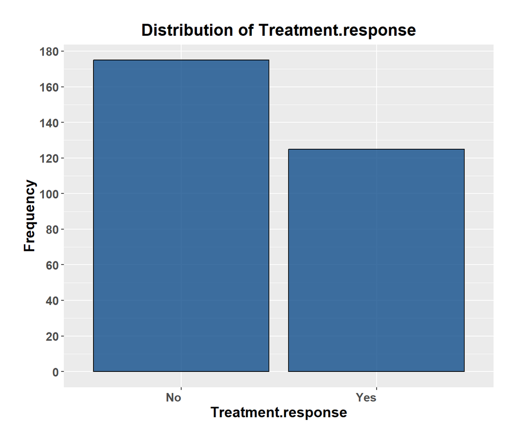

##### Sex

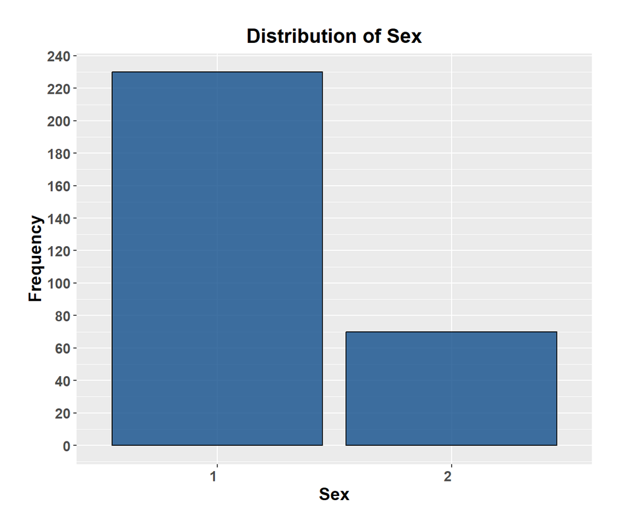

##### Age

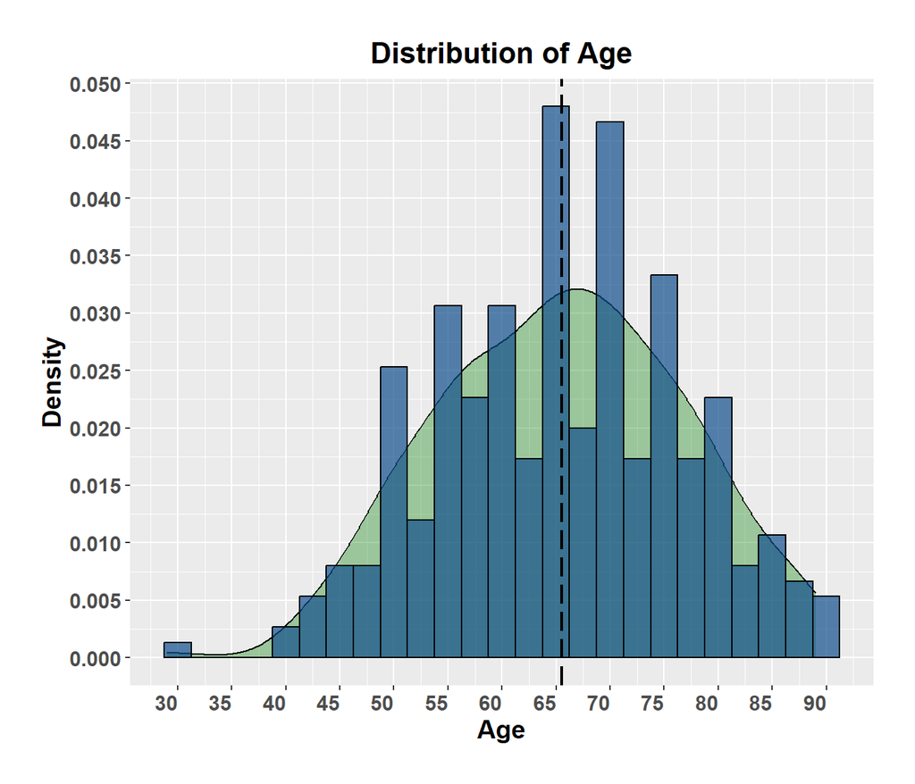

##### Weight

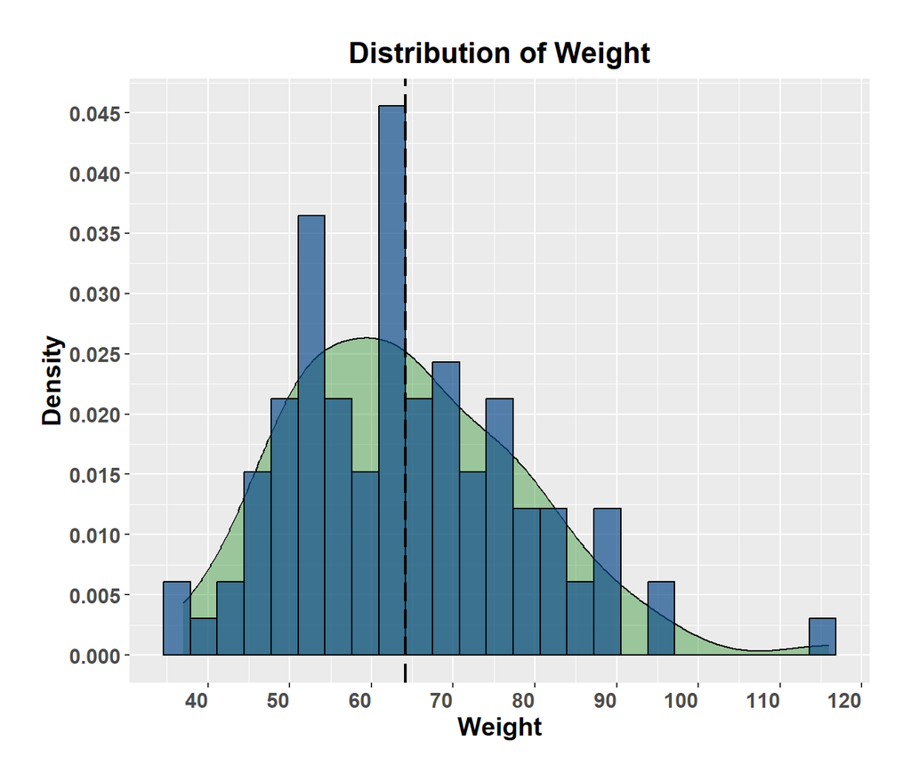

##### Recist.cm

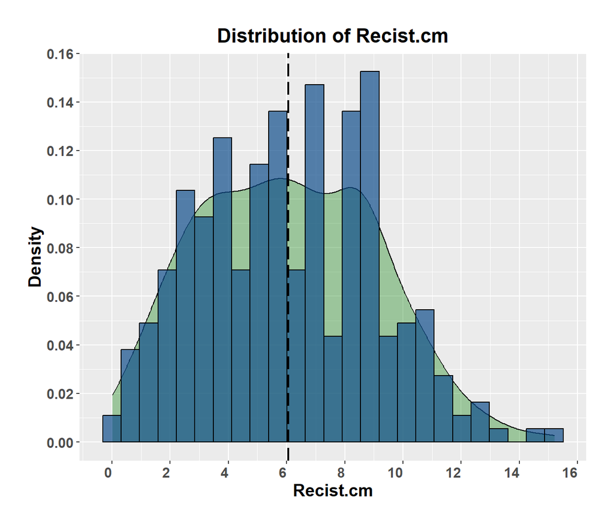

##### Surface.cm2

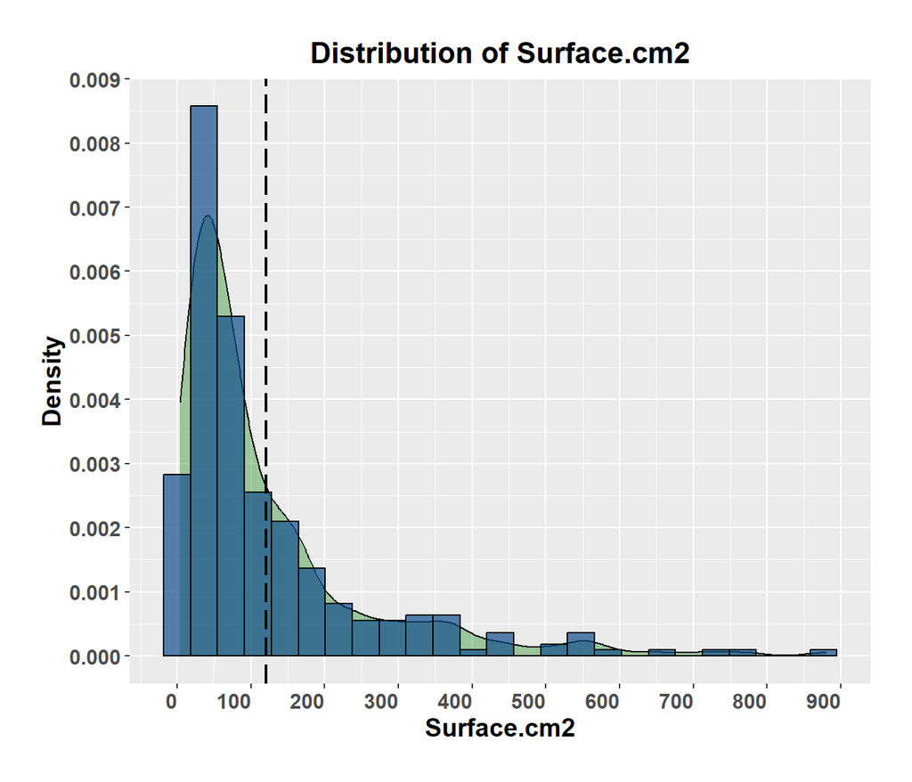

##### Volume.cm3

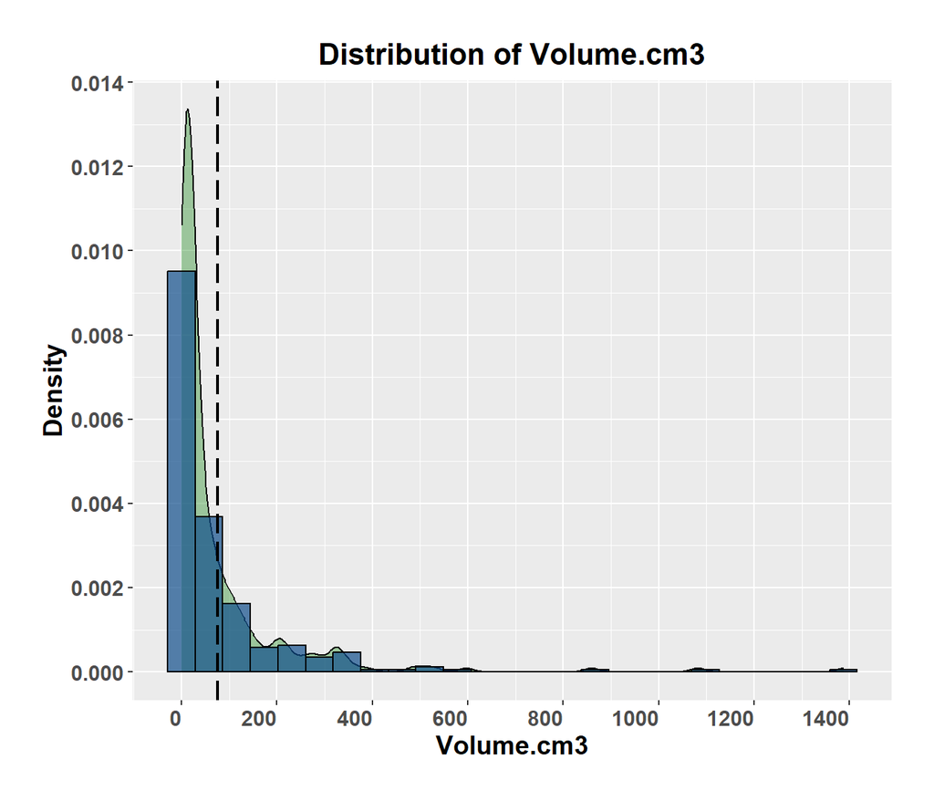

##### Number.of.grey.levels

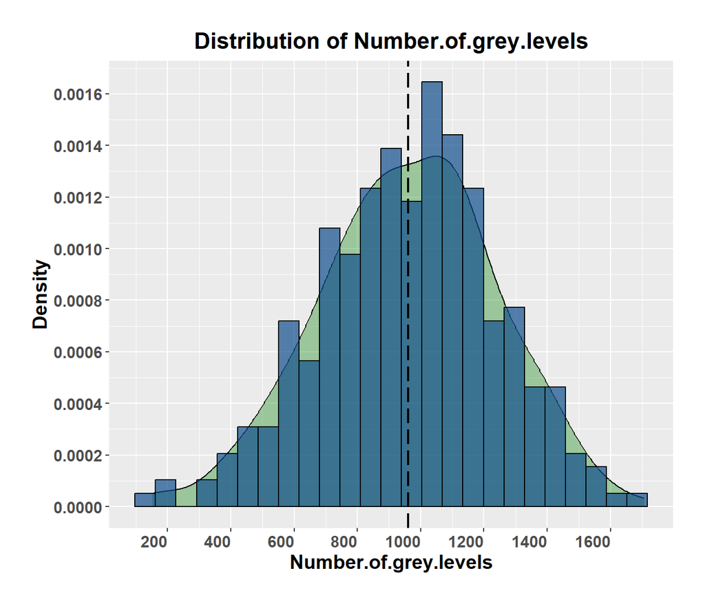

##### Min.value.stat

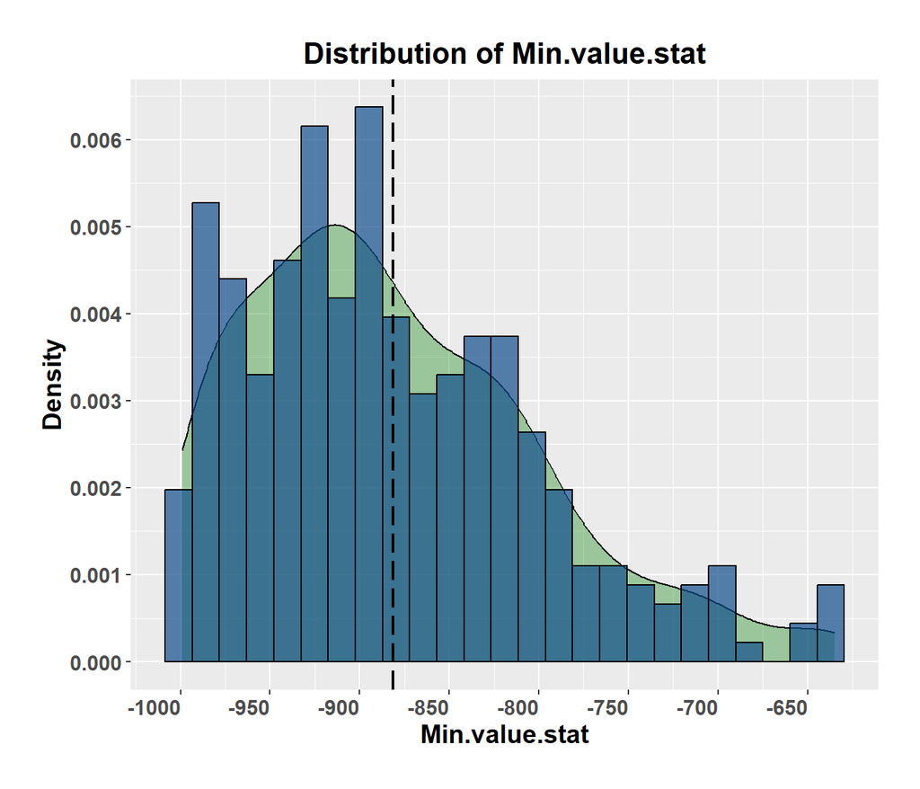

##### Max.value.stat

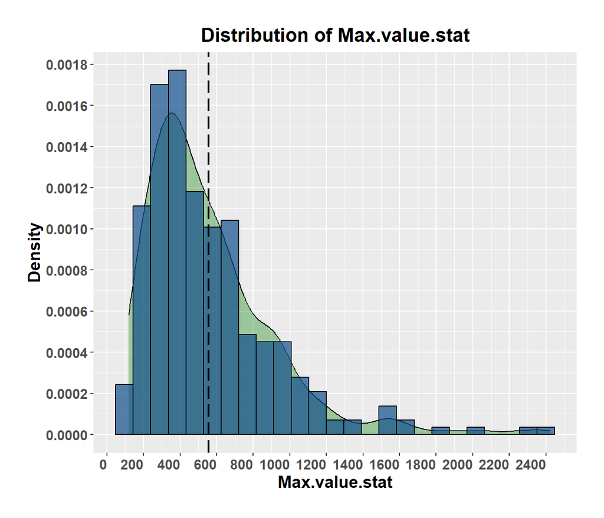

##### Median.value.stat

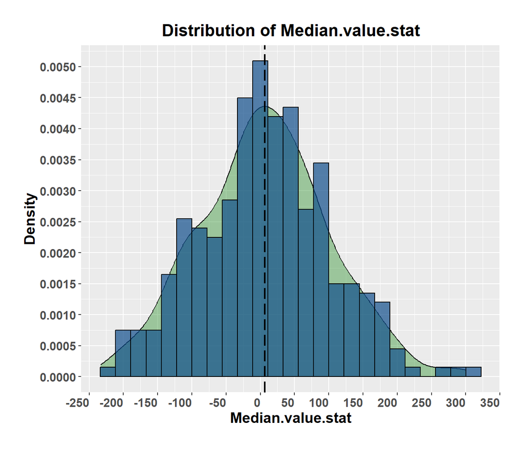

##### Skewness.stat

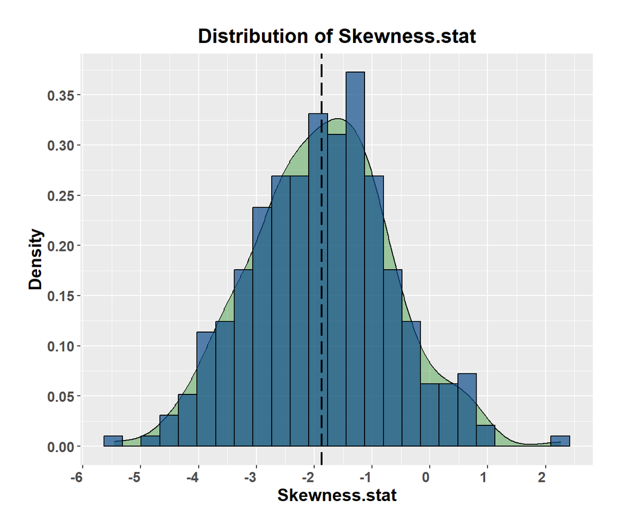

##### Standard.deviation.stat

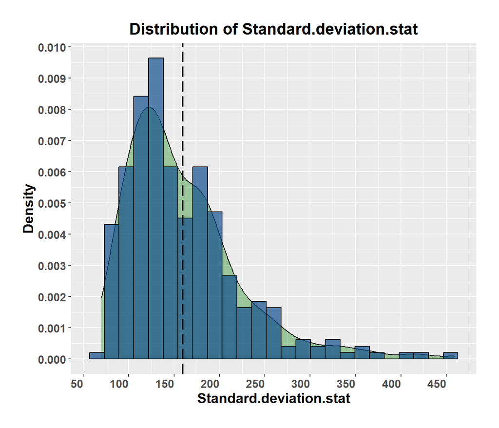

##### Contrast.GLCM

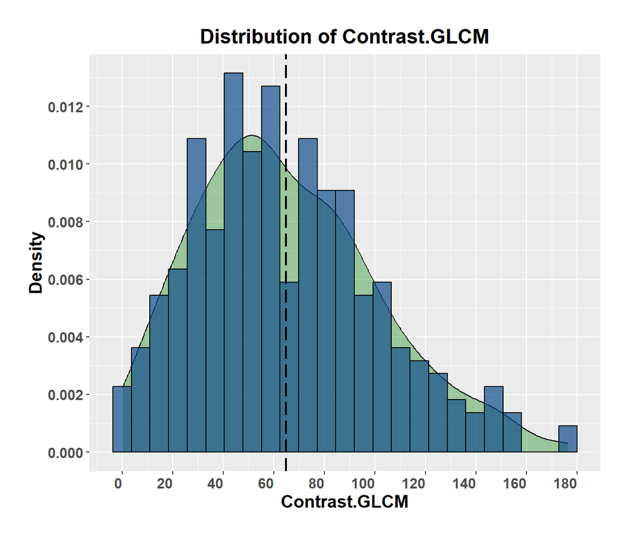

##### Homogeneity.GLCM

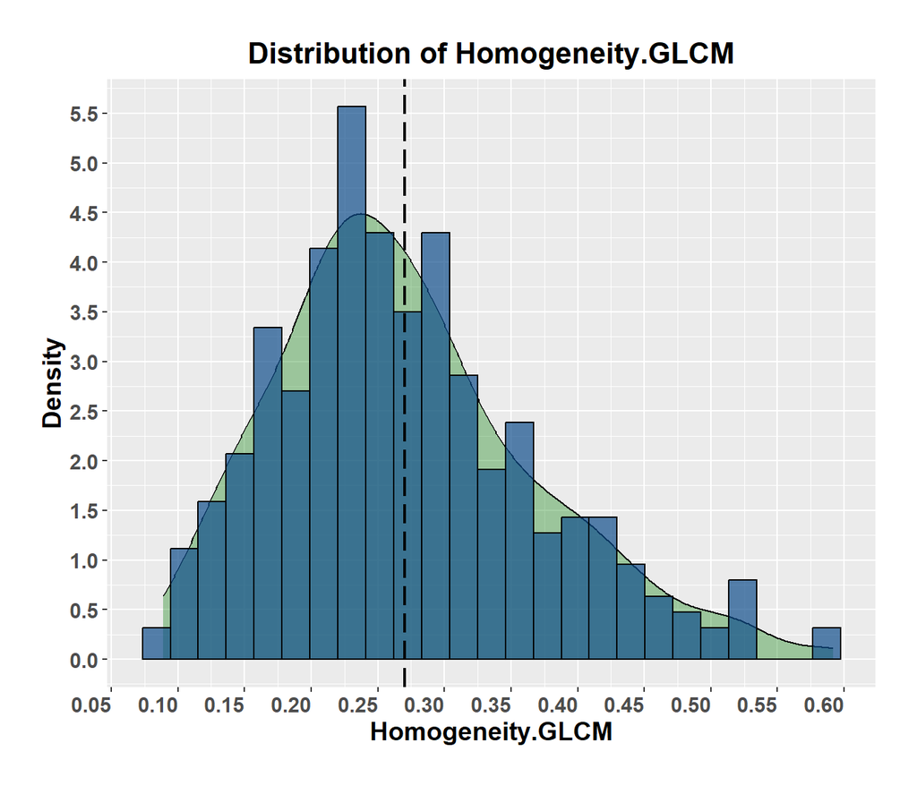

##### Missing.weight

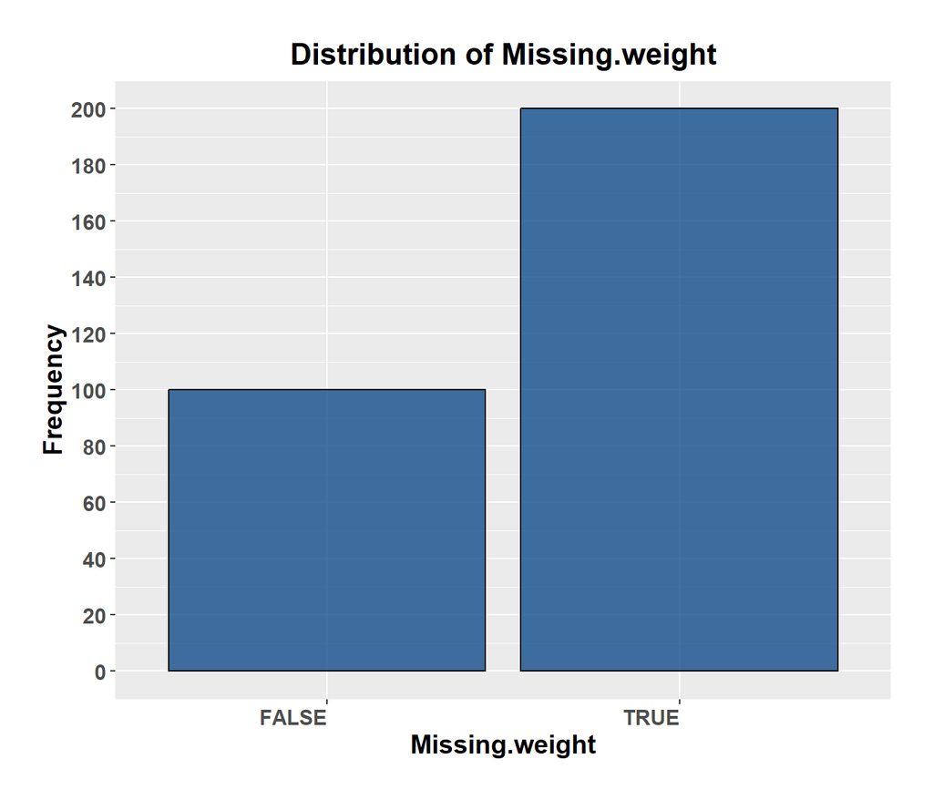

Barplots are used to display categorical distributions, and histograms and juxtaposed density plots are used for numerical distributions.

We can observe that :

- Several of the features are right-skewed, in particular *Surface.cm2*, *Volume.cm3*, *Max.value.stat* and *contrast.GLCM*.
- On the other hand, *Number.of.grey.levels* looks more normally distributed.
- Regarding *Weight*, after all 37kg does not look like an outlier, however on the other side of the distribution, 116kg looks like one (second highest value is 96kg).
- *Age* also seems to display an outlier, with the lowest value being 29yo when the second youngest patient is 41yo.
- Some radiomic features like *Surface* and *Volume* also seem to display outliers, however it is hard to tell for sure at this stage due to their important skewness.

In both *Weight* and *Age* cases, we have no reason to believe these outliers are due to wrong data entry, hence replacing them with the median value is not appropriate. Also, we do not wish to exclude them as the amount of data available is limited. We decide to use Winzorisation[^6] on these variables as it is a good way to make them less influential while preserving information.

```r
## apply windzorisation to weight and age variables
cancer_dat = cancer_dat %>% mutate(
  Weight = DescTools::Winsorize(Weight,probs=c(0.00,0.99), na.rm=T, type = 1),
  Age = DescTools::Winsorize(Age,probs=c(0.01,1), type = 1)
)
```

### Producing New Variables

Given the amount of observations in our data, and the need for explainability of the model, we will not evaluate all 2 by 2 interactions during modeling step as this would reduce the number of degrees of freedom, affect the robustness of our models, and also create high correlations between variables which can make the assessment of features’ importance difficult if not impossible due to multicollinearity. However, we can ‘manually’ derive new biomarkers if we believe these can be pertinent variables to add to our model. Hence, we proceed to create the following radiomics features:

- *Surface to Volume ratio* (cm<sup>-1</sup>)
- *Compactness 1* which is chosen arbitrarily among several similar variables to quantify the deviation of lesion’s volume from a representative spheroid
- *Intensity Range* ( Intensity Interquartile Range would probably be a more appropriate measure as less affected by outliers, however we do not have Intensity percentiles available )

```r
## Add new variables
cancer_dat = cancer_dat %>% mutate(Surface.volume.ratio = Surface.cm2/Volume.cm3,
                                   Compactness.1 = Volume.cm3/(pi^(1/2)*Surface.cm2^(3/2)),
                                   Intensity.range = Max.value.stat - Min.value.stat)

## update quantitative and qualitative variable names
Quant_feats = colnames(cancer_dat %>% select_if(is.numeric))
Quali_vars = colnames(cancer_dat %>% select_if(function(x) is.factor(x) | is.logical(x)))
Features = colnames(cancer_dat)[colnames(cancer_dat)!="Treatment.response"]
```

The distribution of these new features is displayed in the plots below:

```r
# Save current variable names
Variables = c("Surface.volume.ratio","Compactness.1","Intensity.range")

# Save plots in list object
gg0 <- list()
for( i in Variables){
  gg0[[i]] = get_distribution_hist(cancer_dat, i)
}

# Display variable distribution plots in different tabs
for (Var in Variables) {
  cat("##### ",Var,"\n")
  print(gg0[[Var]])
  cat('\n\n')
}
```

##### Surface.volume.ratio

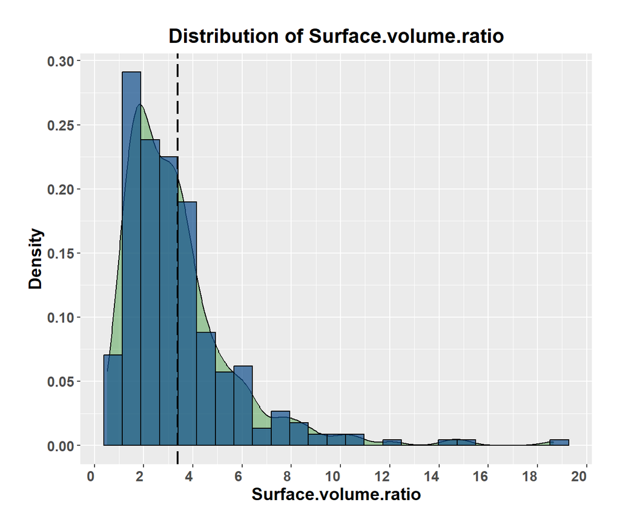

##### Compactness.1

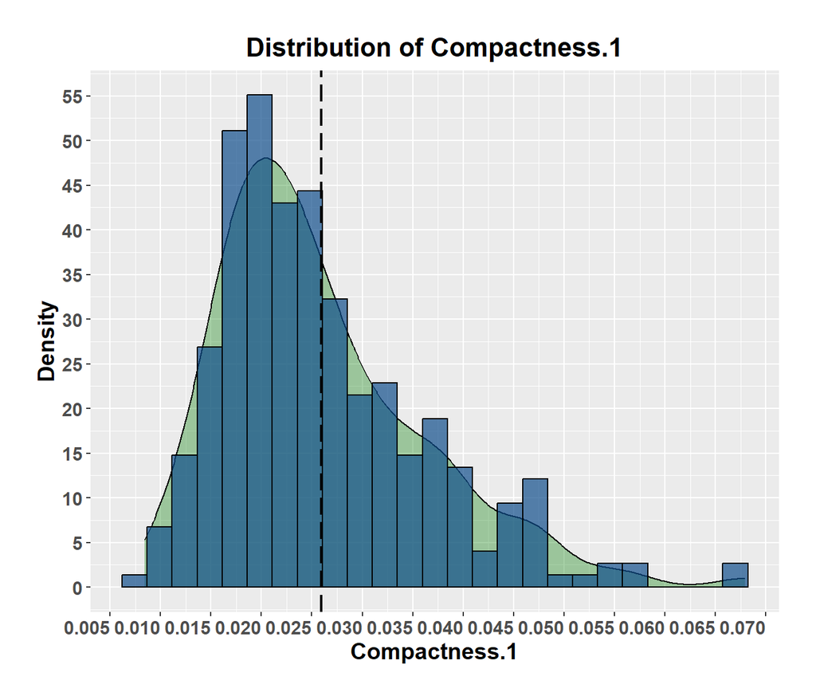

##### Intensity.range

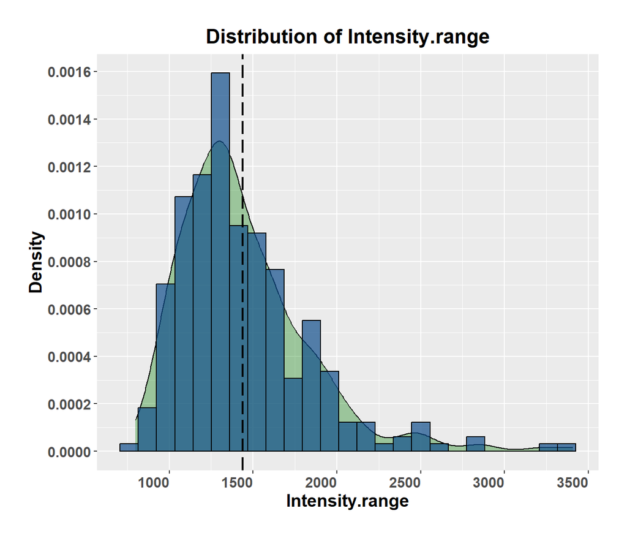

Again we observe that these variables display a right-skewed distribution.

### Bivariate Analysis

In this step of the analysis we examine the 2 by 2 relationships of the different variables in the dataset.

#### Between Target and Explanatory Variables

*Question 2. “Is there any difference between non-responder and responder patients according to their pre-treatment individual features?”*

First, we focus on the connections between the dependent variable (*Treatment.response*) and each independent variable.

These relationships are plotted in the tabs below, using boxplot and density visualisations for numeric features and barplots for categorical features.

```r
## Function to plot boxplot distributions of quantitative features relative to categorical response
get_distribution_boxplot = function(data, column, cat_response){

  # boxplot code
  p=ggplot(data,aes_string(x=cat_response, y=column, fill = cat_response)) +
    #"darkgreen" "forestgreen" '#08519c' 'dodgerblue4'
    geom_violin( alpha = 0.3 ) +
    geom_boxplot(alpha = 0.7) +
    labs( x=cat_response, y=column, title="")+
    scale_y_continuous(breaks = scales::pretty_breaks(n = 10)) +
    scale_fill_manual(values=c('hotpink3', 'dodgerblue4')) +
    theme(
      legend.position="none",
      axis.title.x = element_blank(),
      text = element_text(size=14,face="bold"),
      # axis.text.x = element_blank()
    )+
    coord_flip()

  # density plot code
  p2=ggplot(data,aes_string(x=column, fill = cat_response)) +
    geom_density(position = "fill", alpha = 0.8)+
    labs( x=column, y="Density", title ="") +
    scale_x_continuous(breaks = scales::pretty_breaks(n = 10)) +
    scale_fill_manual(values=c('hotpink3', 'dodgerblue4')) +
    theme(
      legend.position="bottom",
      text = element_text(size=14,face="bold")
    )
  # title plot
  title = paste0("Distribution of ",column," for \nDifferent Levels of ",cat_response)

  return(list(title,p,p2))
}

get_bivariate_barplot = function(data, column, cat_response){

  # barplot code
  p= ggplot(data,aes_string(x=column, fill = cat_response)) +
  geom_bar(position = "dodge",  colour="black",alpha = 0.8) +
  labs( y="Count") +
  scale_y_continuous(breaks = scales::pretty_breaks(n = 10)) +
  scale_fill_manual(values=c('hotpink3', 'dodgerblue4')) +
  theme(
      legend.position="none",
      # axis.title.x = element_blank(),
      text = element_text(size=14,face="bold"),
      # axis.text.x = element_blank()
    ) + coord_flip()

  # colplot code

  proportions <- data %>%
    group_by(.dots = c(column, cat_response)) %>%
    summarise(Count = n())%>%
    group_by(.dots = column) %>%
    mutate(Proportion = Count / sum(Count))


  p2=ggplot(proportions,aes_string(x=column, y="Proportion", fill = cat_response)) +
  geom_col(stat = "identity",  colour="black",alpha=0.8) +
  scale_y_continuous(labels = scales::label_percent(accuracy = 1), #percent
                     breaks = scales::pretty_breaks(n = 10)) +
  scale_fill_manual(values=c('hotpink3', 'dodgerblue4')) +
  theme(
      text = element_text(size=14,face="bold"),
      legend.position="bottom",
      # legend.title=element_text(size=8),
      # legend.text=element_text(size=8)
    ) + coord_flip()


  # title plot
  title = paste0("Distribution of ",column," by ",cat_response)

  return(list(title,p,p2))
}

# Get plots of quantitative and qualitative features in list object
gg0 <- list()
for( i in Features){
  if(i %in% Quant_feats){
      gg0[[i]] = get_distribution_boxplot(cancer_dat, i, "Treatment.response")
  } else if(i %in% Quali_vars){
          gg0[[i]] = get_bivariate_barplot(cancer_dat, i, "Treatment.response")
  }
}

# display plots in tabs
for (Feature in Features) {
  cat("##### ",Feature,"\n")
  grid.newpage()

  if(Feature %in% Quant_feats){
    pushViewport(viewport(layout = grid.layout(3, 1, heights = unit(c(2, 10, 13), "null"))))
     grid.text(gg0[[Feature]][[1]],gp = gpar(fontsize = 16, fontface="bold"), vp = viewport(layout.pos.row = 1, layout.pos.col = 1))
     print(gg0[[Feature]][[2]], vp = viewport(layout.pos.row = 2, layout.pos.col = 1))
     print(gg0[[Feature]][[3]], vp = viewport(layout.pos.row = 3, layout.pos.col = 1))

  } else if(Feature %in% Quali_vars){
    pushViewport(viewport(layout = grid.layout(3, 1, heights = unit(c(2, 10, 10), "null"))))
     grid.text(gg0[[Feature]][[1]],gp = gpar(fontsize = 16, fontface="bold"), vp = viewport(layout.pos.row = 1))
     print(gg0[[Feature]][[2]], vp = viewport(layout.pos.row = 2, layout.pos.col = 1))
     print(gg0[[Feature]][[3]], vp = viewport(layout.pos.row = 3, layout.pos.col = 1))
  }
  cat('\n\n')
}
```

##### Sex

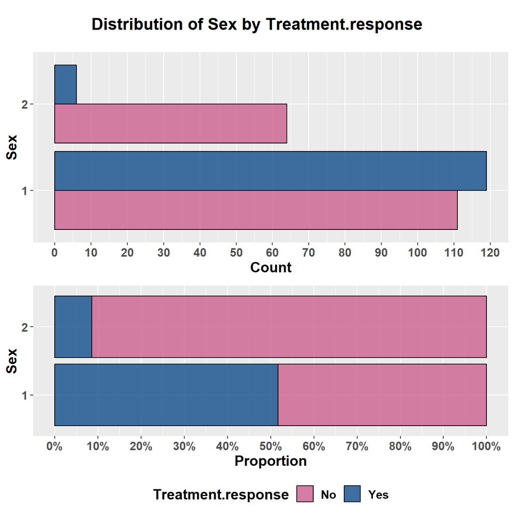

##### Age

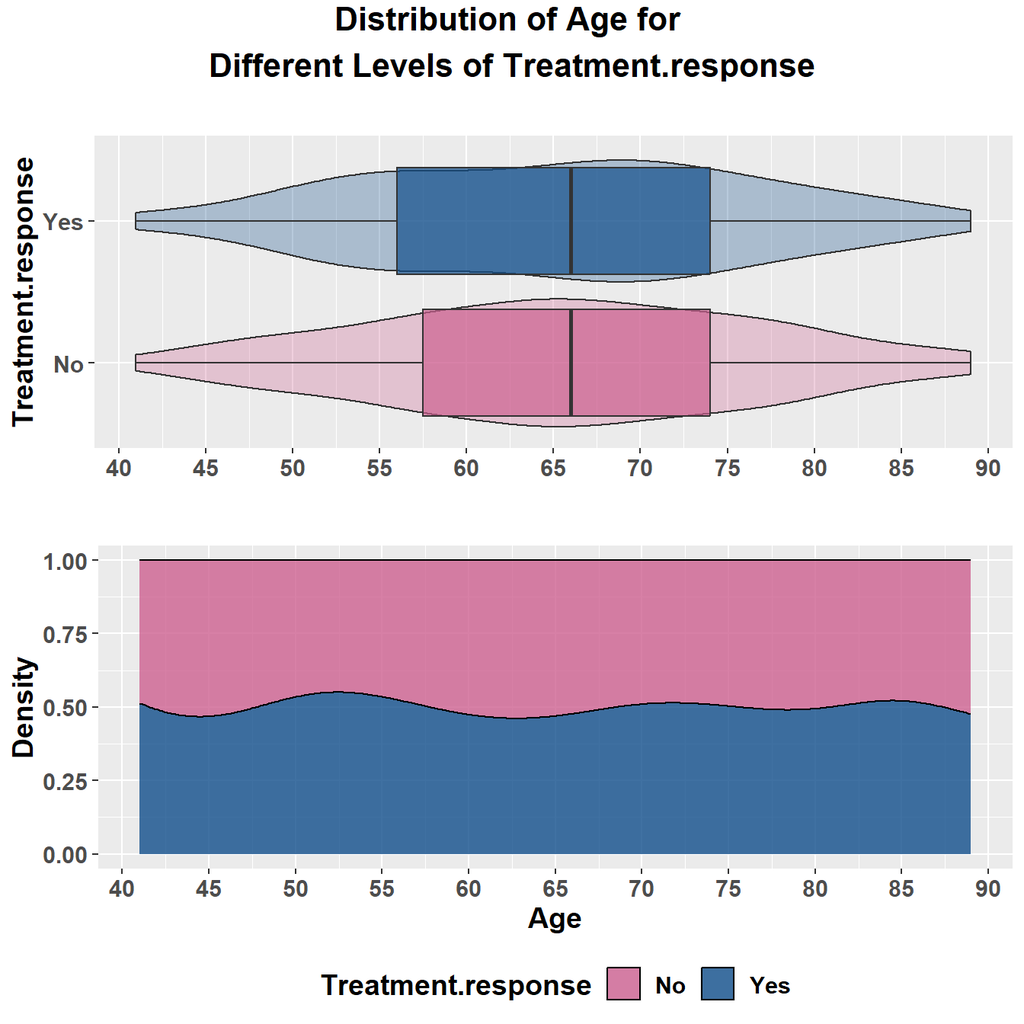

##### Weight

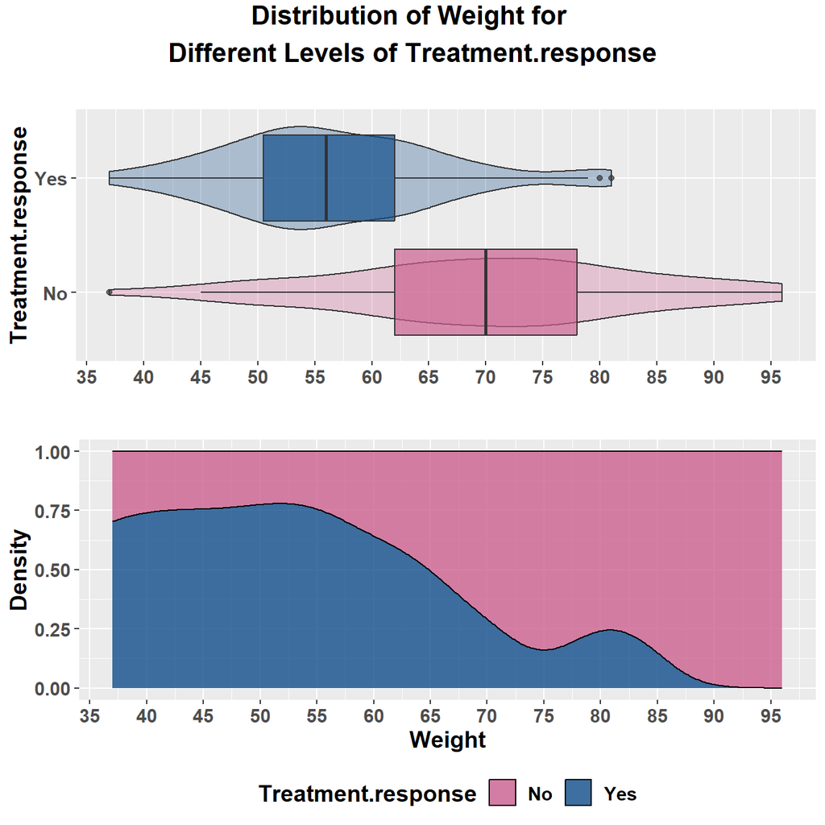

##### Recist.cm

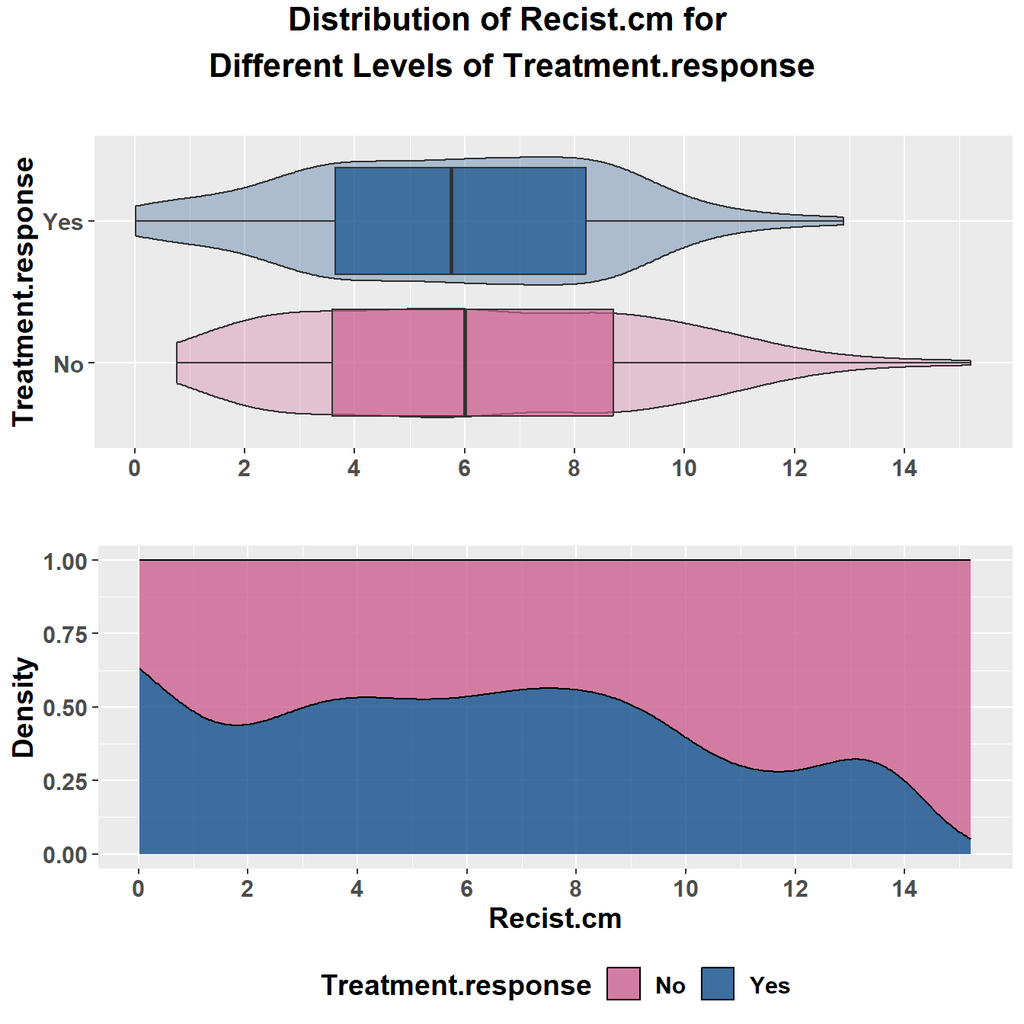

##### Surface.cm2

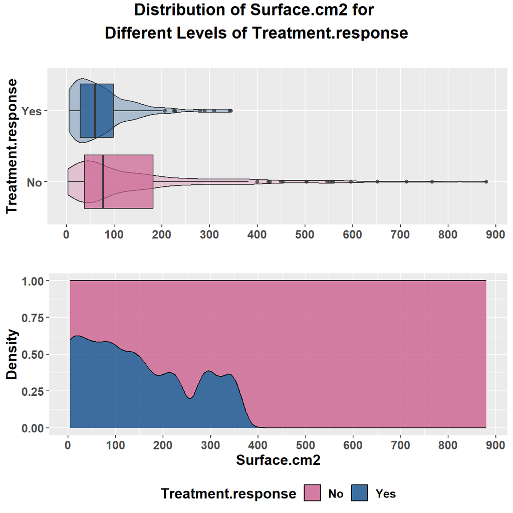

##### Volume.cm3

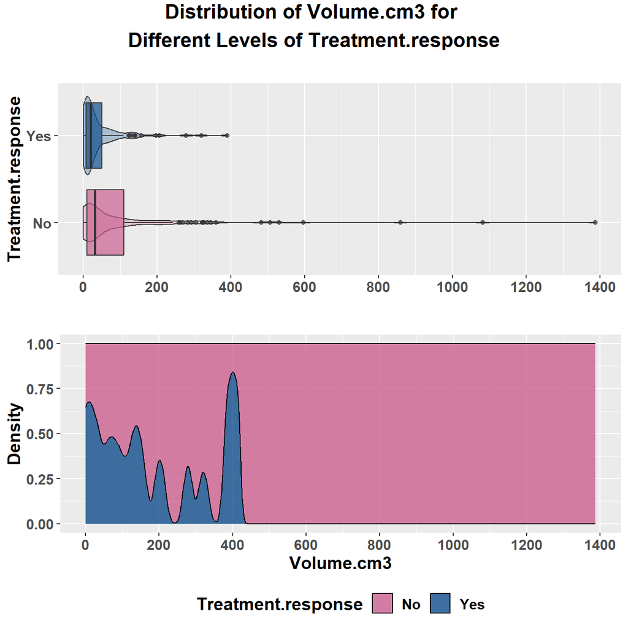

##### Number.of.grey.levels

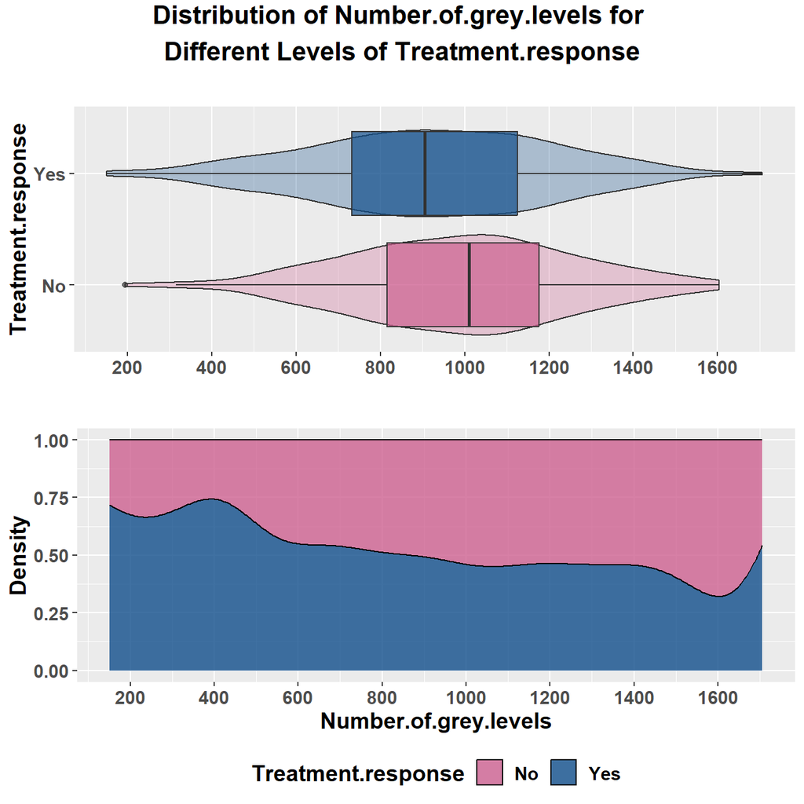

##### Min.value.stat

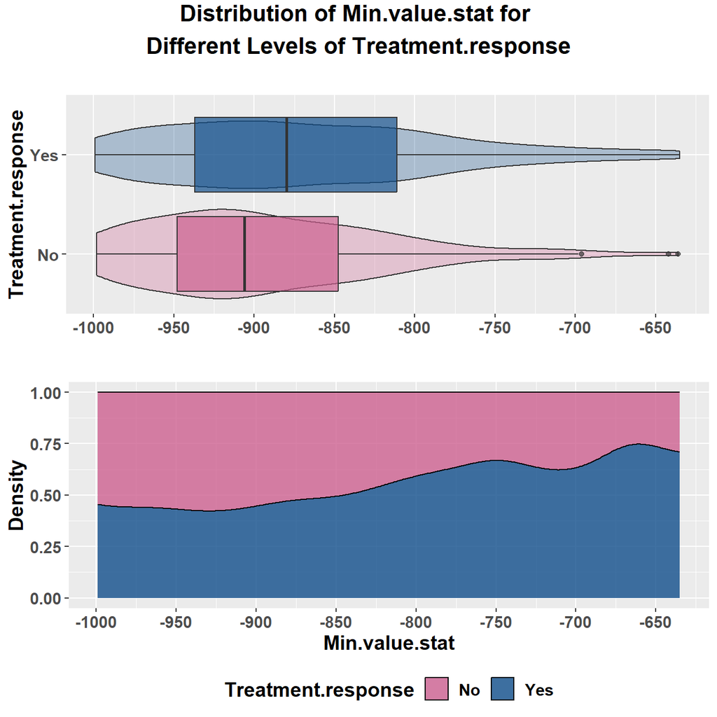

##### Max.value.stat

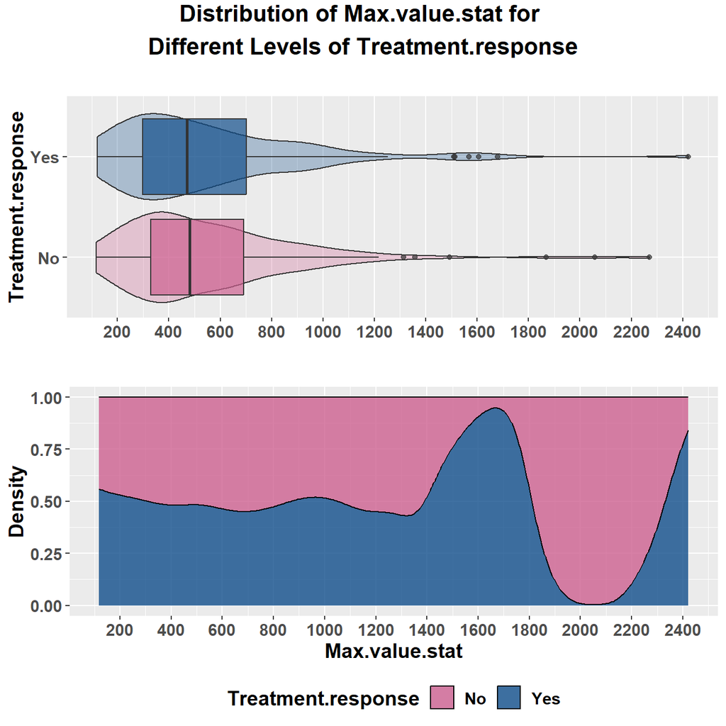

##### Median.value.stat

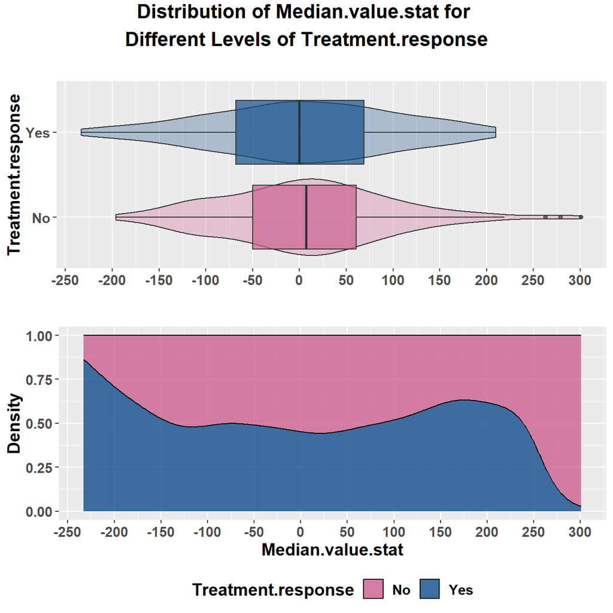

##### Skewness.stat

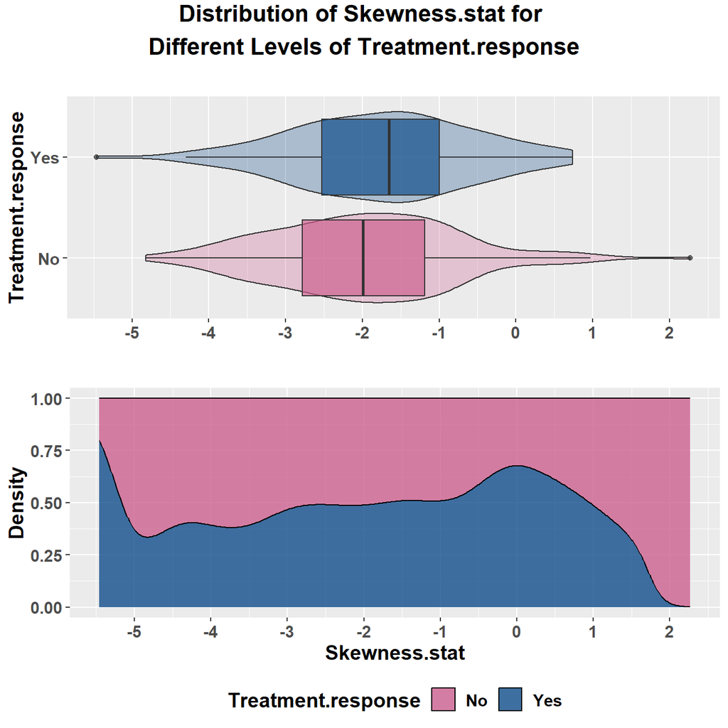

##### Standard.deviation.stat

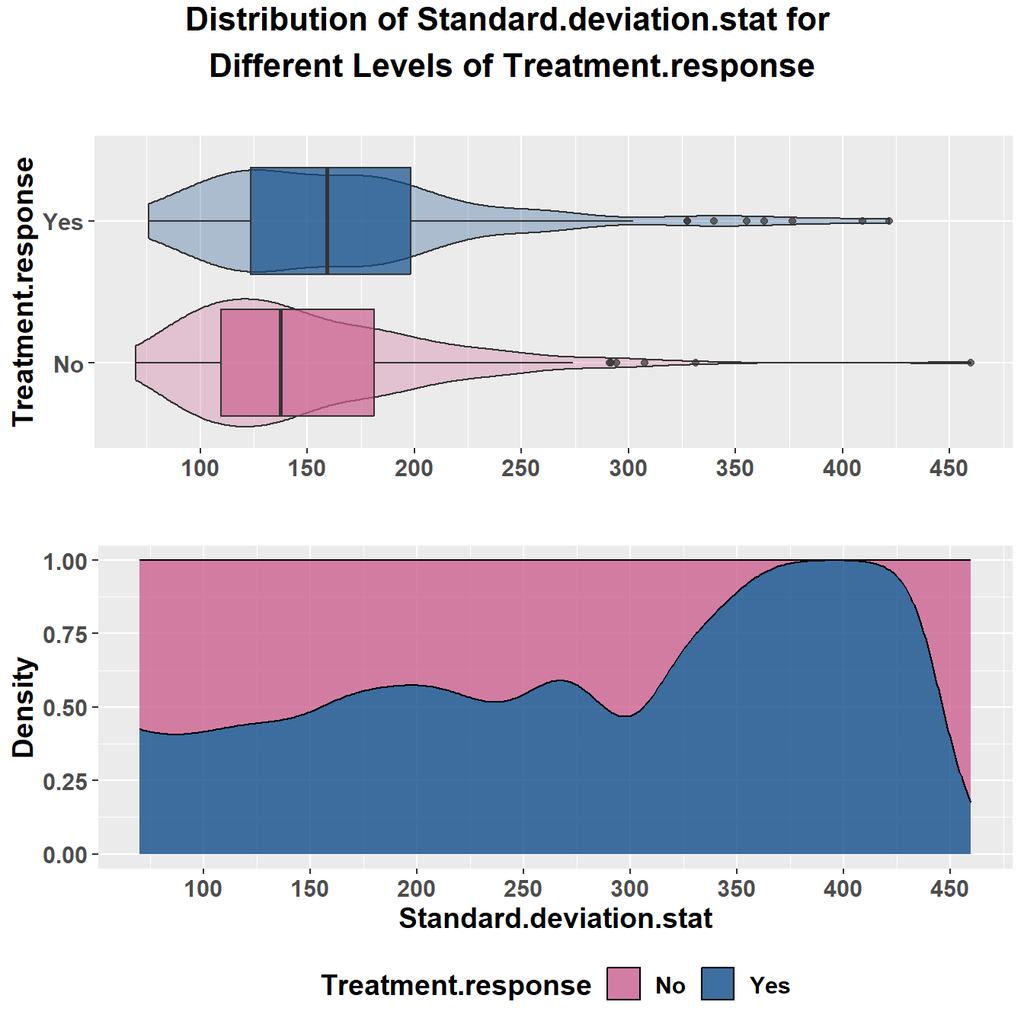

##### Contrast.GLCM

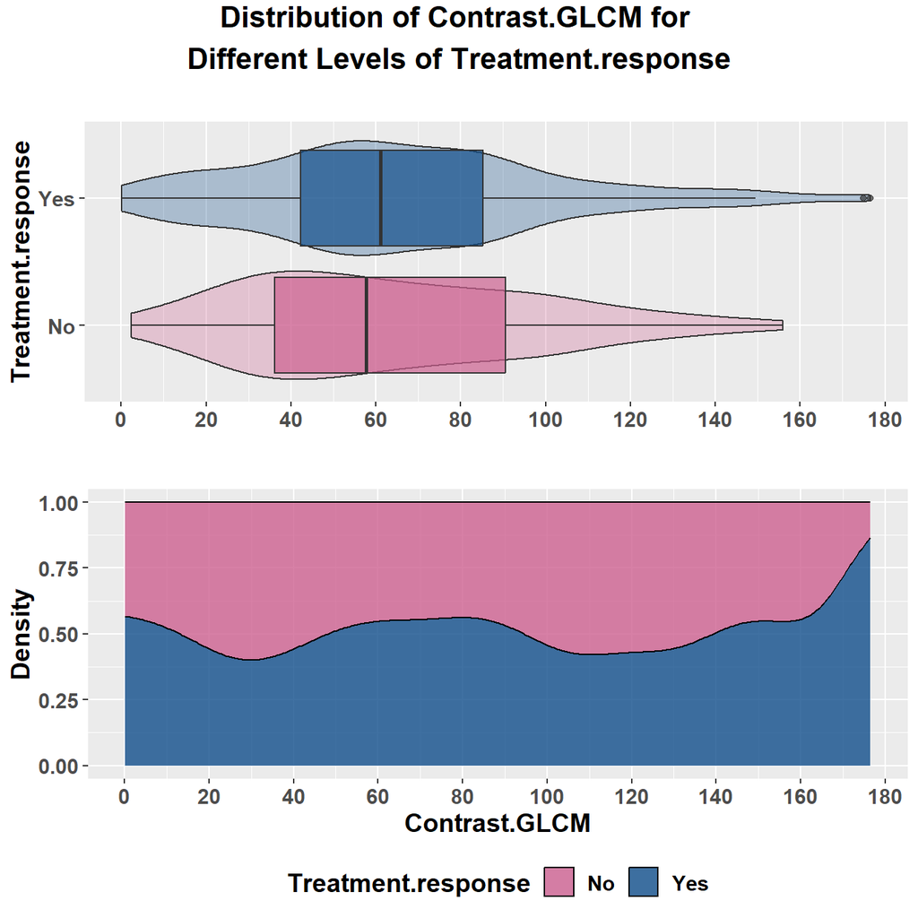